# Mental Health Data Analysis

Ruisha Prasai

2023-10-20

## Introduction

On this page, we conduct an analysis to investigate how students’ mental health impacts their academic well-being. The data used in this study was gathered through a Google Forms survey among university students, focusing on their academic status and mental health. You can access the dataset on Kaggle: https://www.kaggle.com/datasets/shariful07/student-mental-health.

In subsequent sections, we will cover a detailed, step-by-step exploration, utilizing various statistical methods such as ANOVA, Correlation, Regression, Chi-Square, Fisher-test and visualizations to provide insights into the relationship.

## Loading Data

### Setting up my environmnet

Setting up my R environmnet by loading the ‘ggplot2’,‘ggpubr’,‘tidyverse’, ‘broom’, and ’ AICcmodavg’ packages

```r
library(ggplot2)
library(ggpubr)
library(tidyverse)
library(broom)
library(AICcmodavg)
```

### Reading the CSV file

```r
mentalhealth.data <- read.csv("C:/Users/ruish/Downloads/StudentMentalHealth.csv", header = TRUE, colClasses = c("numeric", "numeric", "factor", "factor", "factor", "numeric", "factor", "factor", "factor", "factor", "factor"))
```

### Checking the structure of data to ensure it’s loaded correctly

```r
str(mentalhealth.data)
```

```
## 'data.frame':    100 obs. of  11 variables:
##  $ Gender      : num  1 2 2 1 2 2 1 1 1 2 ...
##  $ Age         : num  18 21 19 22 23 19 23 18 19 18 ...
##  $ Course      : Factor w/ 41 levels "Accounting ",..: 16 23 8 30 33 16 36 4 20 22 ...
##  $ Year        : Factor w/ 4 levels "1","2","3","4": 1 2 1 3 4 2 2 1 2 1 ...
##  $ GPA         : Factor w/ 6 levels "0 - 1.99","2.00 - 2.49",..: 4 4 4 4 4 5 6 5 3 5 ...
##  $ CGPA        : num  3.49 3.49 3.49 3.49 3.49 3.49 3.49 4 2.99 4 ...
##  $ Married     : Factor w/ 2 levels "No","Yes": 1 1 1 2 1 1 2 1 1 1 ...
##  $ Depression  : Factor w/ 2 levels "No","Yes": 2 1 2 2 1 1 2 1 1 1 ...
##  $ Anxiety     : Factor w/ 2 levels "No","Yes": 1 2 2 1 1 1 1 2 1 2 ...
##  $ Panic.Attack: Factor w/ 2 levels "No","Yes": 2 1 2 1 1 2 2 1 1 2 ...
##  $ Specialists : Factor w/ 2 levels "No","Yes": 1 1 1 1 1 1 1 1 1 1 ...
```

### Checking for missing values

```r
summary(mentalhealth.data)
```

```
##      Gender          Age                       Course   Year
##  Min.   :1.00   Min.   :18.00   Engineering       :19   1:42
##  1st Qu.:1.00   1st Qu.:18.00   BCS               :18   2:26
##  Median :1.00   Median :19.00   BIT               : 9   3:24
##  Mean   :1.25   Mean   :20.53   KOE               : 7   4: 8
##  3rd Qu.:1.25   3rd Qu.:23.00   Biomedical science: 4
##  Max.   :2.00   Max.   :24.00   BENL              : 3
##                                 (Other)           :40
##            GPA          CGPA       Married  Depression Anxiety  Panic.Attack
##  0 - 1.99    : 3   Min.   :1.990   No :84   No :65     No :66   No :67
##  2.00 - 2.49 : 2   1st Qu.:3.490   Yes:16   Yes:35     Yes:34   Yes:33
##  2.50 - 2.99 : 4   Median :3.490
##  3.00 - 3.49 :43   Mean   :3.638
##  3.50 - 4.00 :47   3rd Qu.:4.000
##  3.50 - 4.00 : 1   Max.   :4.000
##
##  Specialists
##  No :94
##  Yes: 6
##
##
##
##
##
```

## Analyzing and Data Visulazation

### One-way ANOVA for Gender and GPA

```r
gender_anova <- aov(CGPA ~ Gender, data = mentalhealth.data)
summary(gender_anova)
```

```
##             Df Sum Sq Mean Sq F value Pr(>F)
## Gender       1  0.237  0.2374   1.203  0.275
## Residuals   98 19.339  0.1973
```

The result suggests that there is no statistically significant effect of “Gender” (F value = 1.203, p-value = 0.275) on the GPA(Grade Point Average), as the p-value is greater than the typical significance level of 0.05. Most of the variation in the dependent variable is attributed to the residuals.

Below is the box plot showing this relationship:

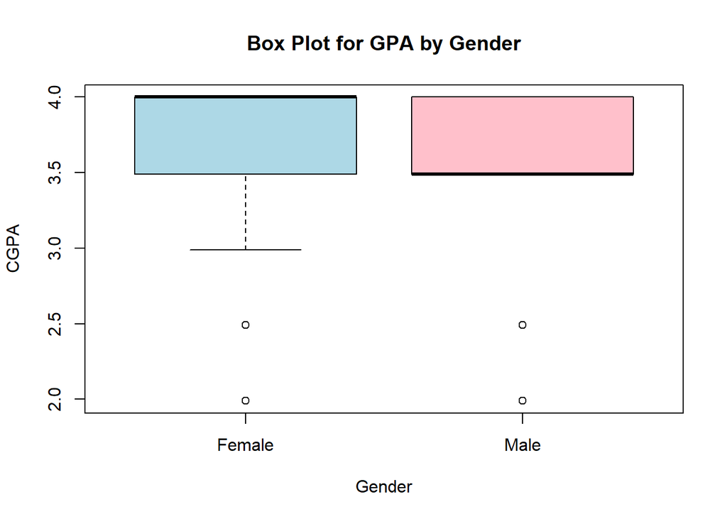

```r
mentalhealth.data$Gender <- factor(mentalhealth.data$Gender, labels = c("Female", "Male"))
genderanova_colors <- c("lightblue", "pink")
boxplot(CGPA ~ Gender, data = mentalhealth.data, col = genderanova_colors, xlab = "Gender", ylab = "CGPA", main = "Box Plot for GPA by Gender")
```

### Two-way ANOVA for Year and Married on GPA

```r
two_way_anova <- aov(CGPA ~ Year * Married, data = mentalhealth.data)
summary(two_way_anova)
```

```
##              Df Sum Sq Mean Sq F value Pr(>F)
## Year          3  0.564 0.18791   0.952  0.419
## Married       1  0.016 0.01559   0.079  0.779
## Year:Married  3  0.832 0.27731   1.404  0.247
## Residuals    92 18.165 0.19744
```

Based on the p-values, it appears that neither “Year,” “Married,” nor the interaction between them has a significant effect on the GPA in this two-way ANOVA analysis.

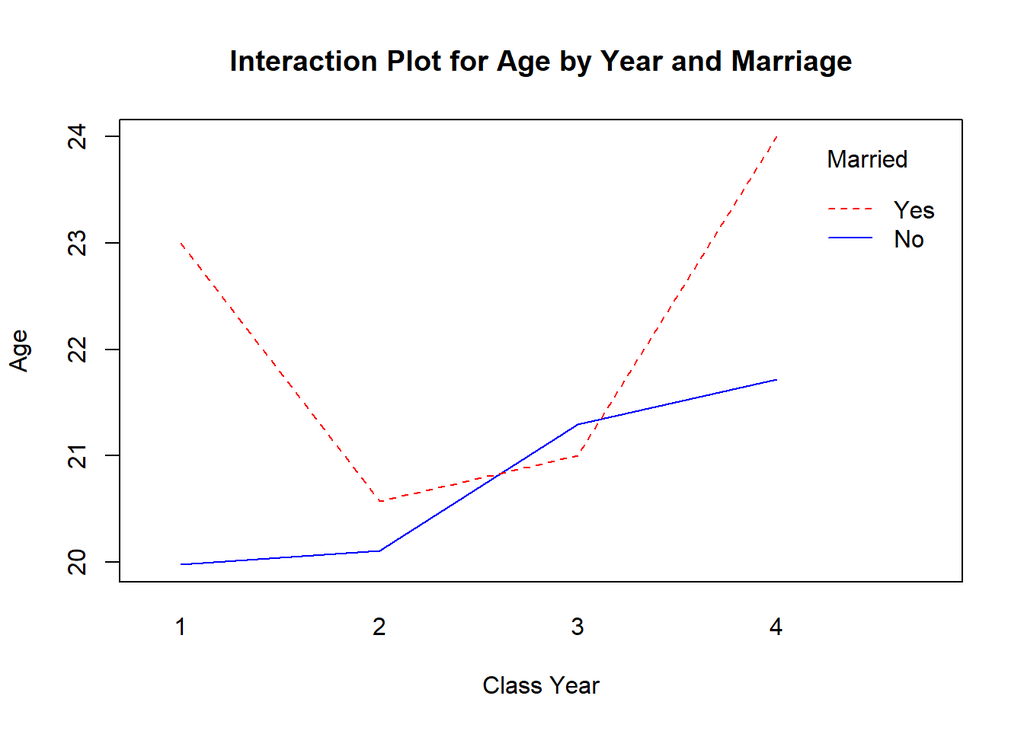

```r
twowayanova_colors <- c("blue", "red", "green")
towwayanova_linetypes <- c(1, 2, 3)
interaction.plot(
  mentalhealth.data$Year,
  mentalhealth.data$Married,
  mentalhealth.data$Age,
  xlab = "Class Year",
  ylab = "Age",
  trace.label = "Married",
  main = "Interaction Plot for Age by Year and Marriage",
  col = twowayanova_colors,
  lty = towwayanova_linetypes
)
```

### Correlation between Age and GPA

```r
correlation_matrix <- cor(mentalhealth.data[c("Age", "CGPA")])
correlation_matrix
```

```
##              Age        CGPA
## Age  1.000000000 0.003159414
## CGPA 0.003159414 1.000000000
```

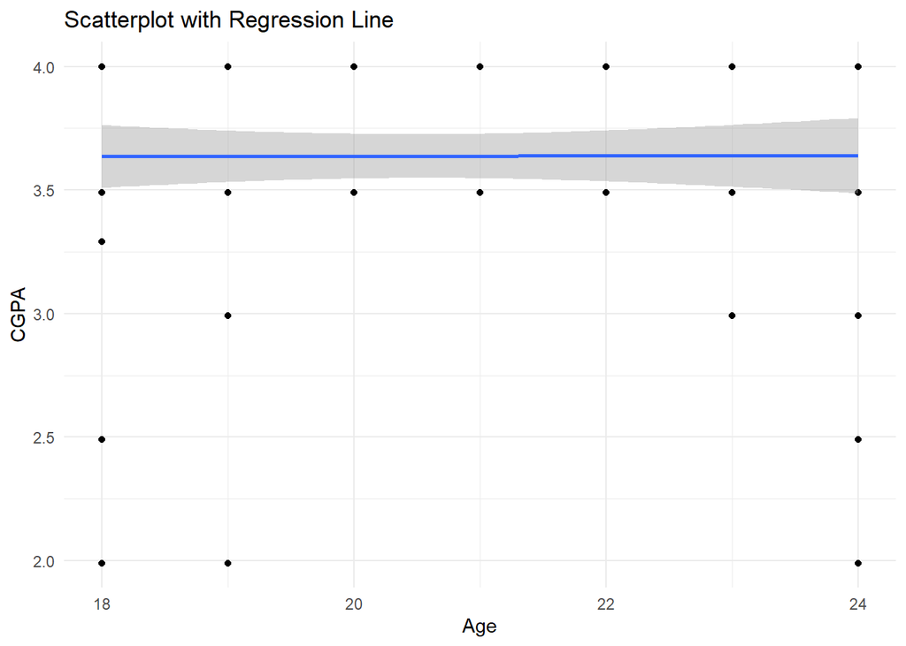

```r
ggplot(mentalhealth.data, aes(x = Age, y = CGPA)) +
  geom_point() +
  geom_smooth(method = "lm") +
  theme_minimal() +
  labs(x = "Age", y = "CGPA") +
  ggtitle("Scatterplot with Regression Line")
```

Both the r value and plot shows shows that there is a very weak positive correlation (0.003) between “Age” and “CGPA,” indicating that there’s almost no linear relationship between the two variables in this dataset.

### Linear regression with “Age” as the independent variable and “CGPA” as the dependent variable.

```r
linear_regression_model <- lm(CGPA ~ Age, data = mentalhealth.data)
summary(linear_regression_model)
```

```
##
## Call:
## lm(formula = CGPA ~ Age, data = mentalhealth.data)
##
## Residuals:
##     Min      1Q  Median      3Q     Max
## -1.6496 -0.1480 -0.1462  0.3627  0.3638
##
## Coefficients:
##              Estimate Std. Error t value Pr(>|t|)
## (Intercept) 3.6260456  0.3721177   9.744 4.34e-16 ***
## Age         0.0005628  0.0179943   0.031    0.975
## ---
## Signif. codes:  0 '***' 0.001 '**' 0.01 '*' 0.05 '.' 0.1 ' ' 1
##
## Residual standard error: 0.4469 on 98 degrees of freedom
## Multiple R-squared:  9.982e-06,  Adjusted R-squared:  -0.01019
## F-statistic: 0.0009782 on 1 and 98 DF,  p-value: 0.9751
```

The linear regression model does not provide a significant relationship between “Age” and “GPA” since the p-value for the “Age” coefficient is very high (0.975). The model explains very little of the variability in GPA (Multiple R-squared is close to zero), and the relationship is not statistically significant.

Below is the plot to represent this:

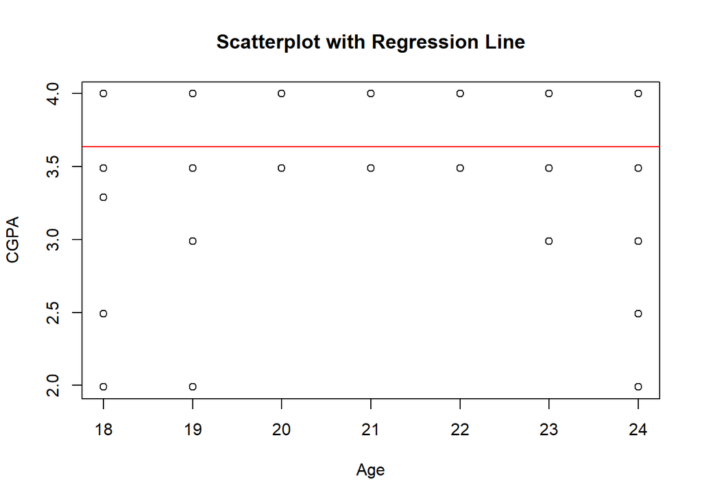

```r
plot(mentalhealth.data$Age, mentalhealth.data$CGPA, xlab = "Age", ylab = "CGPA", main = "Scatterplot with Regression Line")
abline(linear_regression_model, col = "red")
```

### Contingency Tables for Depression, Panic.Attack, Anxiety and Specialists

#### 1. Depression and Specialists

```r
contingency_table_depressionspe <- table(mentalhealth.data$Depression, mentalhealth.data$Specialists)
fisherdepressionspe <- fisher.test(contingency_table_depressionspe)
fisherdepressionspe
```

```
##
##  Fisher's Exact Test for Count Data
##
## data:  contingency_table_depressionspe
## p-value = 0.001362
## alternative hypothesis: true odds ratio is not equal to 1
## 95 percent confidence interval:
##  2.417451      Inf
## sample estimates:
## odds ratio
##        Inf
```

In the context of specialists and depression, the p-value of 0.001362 suggests a statistically significant relationship. The odds ratio being infinite (Inf) indicates that the odds of depression are significantly higher among students seeking specialists, and the 95 percent confidence interval is entirely above 2.417451, further supporting this association.This makes sense as people who suffer from depression have higher probability of seeking specialists.

Note: Here, we used fisher test instead of Chi Square due to potential issues with the validity of the chi-squared test results.

#### 2. Depression and Panic Attack

```r
contingency_table_depressionpanic <- table(mentalhealth.data$Depression, mentalhealth.data$Panic.Attack)
chi_squared_test_depressionpanic <- chisq.test(contingency_table_depressionpanic)
chi_squared_test_depressionpanic
```

```
##
##  Pearson's Chi-squared test with Yates' continuity correction
##
## data:  contingency_table_depressionpanic
## X-squared = 4.8712, df = 1, p-value = 0.02731
```

With a p-value of 0.02731, it appears that there is evidence of a statistically significant association between Panic Attack and Depression. In other words, the relationship between these two variables is not due to random chance but suggests that they are related in some way.

Since the association between “Depression” and “Panic Attack” is significant, we are going to plot for residuals. The plot helps you visualize which categories have the largest deviations from what would be expected by chance in the chi-squared test, providing insights into the relationship between “Depression” and “Panic Attack.”

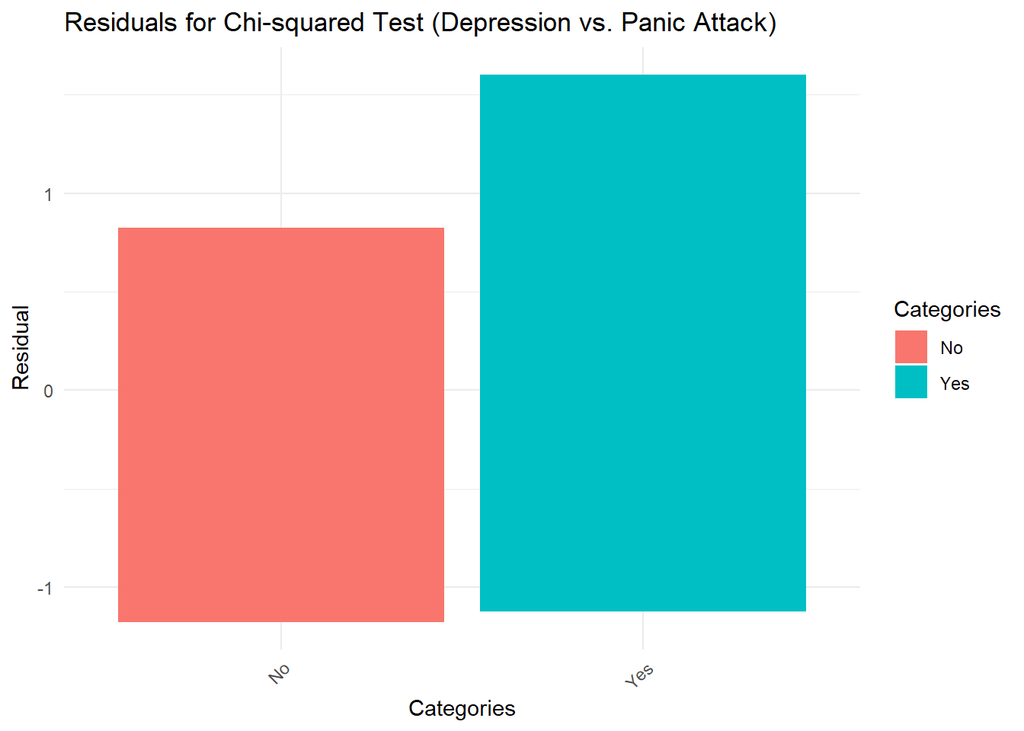

```r
depressionpanicresiduals <- chi_squared_test_depressionpanic$residuals
data <- data.frame(
  Categories = rownames(depressionpanicresiduals),
  Residual = as.numeric(depressionpanicresiduals)
)

ggplot(data, aes(x = Categories, y = Residual, fill = Categories)) +
  geom_bar(stat = "identity") +
  labs(title = "Residuals for Chi-squared Test (Depression vs. Panic Attack)", y = "Residual") +
  theme_minimal() +
  theme(axis.text.x = element_text(angle = 45, hjust = 1))
```

#### 3. Anxiety and Specialists

```r
contingency_table_anxietyspe <- table(mentalhealth.data$Anxiety, mentalhealth.data$Specialists)
fisheranxietyspe <- fisher.test(contingency_table_anxietyspe)
fisheranxietyspe
```

```
##
##  Fisher's Exact Test for Count Data
##
## data:  contingency_table_anxietyspe
## p-value = 0.4059
## alternative hypothesis: true odds ratio is not equal to 1
## 95 percent confidence interval:
##   0.2551973 15.9428660
## sample estimates:
## odds ratio
##   2.016839
```

The Fisher’s Exact Test suggests that there is no statistically significant association between experiencing anxiety and seeking Specialists, as the p-value (0.4059) is greater than the typical significance level of 0.05, and the 95% confidence interval for the odds ratio includes 1. The estimated odds ratio is 2.016839, indicating a mild positive association, but it is not statistically significant.

Note: Here, we used fisher test instead of Chi Square due to potential issues with the validity of the chi-squared test results.

#### 4. Panic Attack and Specialists

```r
contingency_table_panicspe <- table(mentalhealth.data$Panic.Attack, mentalhealth.data$Specialists)
fisherpanicspe <- fisher.test(contingency_table_panicspe)
fisherpanicspe
```

```
##
##  Fisher's Exact Test for Count Data
##
## data:  contingency_table_panicspe
## p-value = 0.09017
## alternative hypothesis: true odds ratio is not equal to 1
## 95 percent confidence interval:
##   0.5938495 51.3055768
## sample estimates:
## odds ratio
##     4.4085
```

The result of Fisher’s Exact Test suggests that the association between Panic Attacks and seeking Specialists is not statistically significant (p-value = 0.09017), indicating that there may not be a strong relationship between the two variables. The estimated odds ratio of 4.4085 implies that the odds of experiencing Panic Attacks and visiting Specialists are 4.4085 times higher than not visiting, but this result is not highly significant given the p-value.

Note: Here, we used fisher test instead of Chi Square due to potential issues with the validity of the chi-squared test results.

#### 5. Depression and Anxiety

```r
contingency_table_depressionanxiety <- table(mentalhealth.data$Depression, mentalhealth.data$Anxiety)
chi_squared_test_depressionanxiety <- chisq.test(contingency_table_depressionanxiety )
chi_squared_test_depressionanxiety
```

```
##
##  Pearson's Chi-squared test with Yates' continuity correction
##
## data:  contingency_table_depressionanxiety
## X-squared = 6.1429, df = 1, p-value = 0.01319
```

The result of the chi-squared test indicates that there is a statistically significant association between “Depression” and “Anxiety.” This suggests that the presence or absence of one of these conditions is not independent of the presence or absence of the other, and they may be related in some manner.

Since the association between “Depression” and “Anxiety” is significant, we are going to plot for residuals.

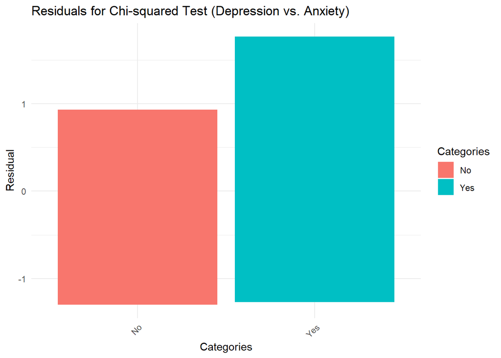

```r
depressionanxietyresiduals <- chi_squared_test_depressionanxiety$residuals
data <- data.frame(
  Categories = rownames(depressionanxietyresiduals),
  Residual = as.numeric(depressionanxietyresiduals)
)

ggplot(data, aes(x = Categories, y = Residual, fill = Categories)) +
  geom_bar(stat = "identity") +
  labs(title = "Residuals for Chi-squared Test (Depression vs. Anxiety)", y = "Residual") +
  theme_minimal() +
  theme(axis.text.x = element_text(angle = 45, hjust = 1))
```

#### 6. Panic Attack and Anxiety

```r
contingency_table_panicanxiety <- table(mentalhealth.data$Panic.Attack, mentalhealth.data$Anxiety)
chi_squared_test_panicanxiety <- chisq.test(contingency_table_panicanxiety )
chi_squared_test_panicanxiety
```

```
##
##  Pearson's Chi-squared test with Yates' continuity correction
##
## data:  contingency_table_panicanxiety
## X-squared = 0.33022, df = 1, p-value = 0.5655
```

This result suggests that there is no strong evidence to conclude that “Panic Attack” and “Anxiety” are significantly related based on the data and the test performed. The relationship between these two variables may not be substantial, and they may be relatively independent of each other in the given dataset.